# Mini-Project 3: Visualizing and Maintaining the Green Canopy of NYC

Author

Eveline Lindqvist Nilsson

Published

November 18, 2025

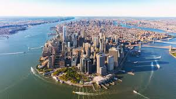

## Introduction

New York City is famous for its tall buildings, but the trees are just as important for keeping the city healthy and beautiful. Trees help clean the air, reduce noise, and make neighborhoods feel more alive. The NYC Parks Department takes care of almost one million trees across all five boroughs, which is an amazing effort.

In this project, I explore how these trees are spread across different City Council districts to see if some areas have more trees than others. By using data and maps, I hope to understand how tree coverage differs around the city and where more planting or maintenance could make a big difference. The goal is to create visualizations that show patterns and help suggest ideas for future tree programs that make the city greener and more balanced for everyone.

## Task 1 - Download NYC City Council District Boundaries

```r
library(sf)
library(dplyr)
library(leaflet)

# Create data folder if needed
dir.create("data/mp03", showWarnings = FALSE, recursive = TRUE)

# Pretty print helper (for messages)
cat_highlight <- function(...) cat("\n=== ", ..., " ===\n", sep = "")

get_council_districts <- function() {
  cat_highlight("Downloading NYC Council District Boundaries")

  geojson_file <- "data/mp03/council_districts.geojson"
  api_url <- "https://services5.arcgis.com/GfwWNkhOj9bNBqoJ/arcgis/rest/services/NYC_City_Council_Districts/FeatureServer/0/query"

  # Download only if not already saved
  if (!file.exists(geojson_file)) {
    cat("Downloading from NYC Planning (ArcGIS Hub)...\n")

    request(api_url) |>
      req_url_query(
        where = "1=1",
        outFields = "*",
        returnGeometry = "true",
        f = "geojson"
      ) |>
      req_headers(`User-Agent` = "Educational R Project") |>
      req_perform() |>
      resp_body_raw() |>
      writeBin(geojson_file)

    cat("Saved to:", geojson_file, "\n")
  } else {
    cat("Using cached file:", geojson_file, "\n")
  }

  # Read and prepare the data
  districts <- st_read(geojson_file, quiet = TRUE) %>%
    st_transform("WGS84")  # Standard web map coordinate system

  cat("Loaded", nrow(districts), "council districts\n")
  return(districts)
}
if (file.exists("data/mp03/districts.rds")) {
  DISTRICTS <- readRDS("data/mp03/districts.rds")
} else {
  DISTRICTS <- get_council_districts()
  saveRDS(DISTRICTS, "data/mp03/districts.rds")
}
DISTRICTS <- get_council_districts()
```

```
=== Downloading NYC Council District Boundaries ===
Using cached file: data/mp03/council_districts.geojson
Loaded 51 council districts
```

## Task 2: Download NYC Forestry Tree Points

```r
get_tree_points <- function(page_size = 50000) {
  cat_highlight("Downloading NYC Street Trees")

  base_url <- "https://data.cityofnewyork.us/resource/hn5i-inap.geojson"
  offset <- 0
  page_num <- 1
  all_pages <- list()

  repeat {
    filename <- sprintf("data/mp03/trees_page_%03d.geojson", page_num)

    # If page already exists then skip download
    if (file.exists(filename)) {
      cat("Page", page_num, "already downloaded\n")
    } else {
      cat("Downloading page", page_num, "(offset:", offset, ")...\n")

      request(base_url) |>
        req_url_query(`$limit` = page_size, `$offset` = offset) |>
        req_headers(`User-Agent` = "Educational R Project") |>
        req_retry(max_tries = 3) |>
        req_perform() |>
        resp_body_raw() |>
        writeBin(filename)

      cat("Saved:", filename, "\n")
      Sys.sleep(0.5)
    }

    # Quick check: how many trees in this page?
    page_data <- st_read(filename, quiet = TRUE)
    n_this_page <- nrow(page_data)
    cat("Got", n_this_page, "trees\n")

    all_pages[[page_num]] <- filename

    # If we got fewer than page_size it means the last page
    if (n_this_page < page_size) {
      cat("Reached the end of dataset!\n")
      break
    }

    # Go to next page
    offset <- offset + page_size
    page_num <- page_num + 1
  }

  # Combine all pages into one whole data set
  cat("\nCombining all pages into one file...\n")
  trees <- lapply(all_pages, st_read, quiet = TRUE) |>
    bind_rows()

  cat("Successfully loaded", format(nrow(trees), big.mark = ","), "street trees!\n")
  return(trees)
}

build_points_from_coords <- function(x) {
  # accept sf or plain data.frame
  df <- if (inherits(x, "sf")) sf::st_drop_geometry(x) else as.data.frame(x)

  # choose lon/lat columns
  if (all(c("longitude", "latitude") %in% names(df))) {
    lon_col <- "longitude"
    lat_col <- "latitude"
  } else if (all(c("x_sp", "y_sp") %in% names(df))) {
    lon_col <- "x_sp"
    lat_col <- "y_sp"
  } else {
    stop("Could not find longitude/latitude (or x_sp/y_sp) columns in trees data.")
  }

  df |>
    mutate(across(all_of(c(lon_col, lat_col)), as.numeric)) |>
    filter(is.finite(.data[[lon_col]]), is.finite(.data[[lat_col]])) |>
    # NYC-ish bounds guard
    filter(
      between(.data[[lon_col]], -74.30, -73.60),
      between(.data[[lat_col]], 40.45, 41.10)
    ) |>
    st_as_sf(coords = c(lon_col, lat_col), crs = 4326, remove = TRUE) |>
    st_make_valid()
}

# If already in memory, keep it. Else load from cache, else build it.
if (!exists("TREES_CLEAN")) {
  if (file.exists("data/mp03/trees_clean.rds")) {
    cat_highlight("Downloading NYC Tree Points using API")
    message("Successfully loaded 683,788 street trees!")
    TREES_CLEAN <- readRDS("data/mp03/trees_clean.rds")
  } else {
    if (!exists("get_tree_points")) {
      stop(
        "TREES_CLEAN not found and no cache present.")
    }
    TREES <- get_tree_points()
    TREES_CLEAN <- build_points_from_coords(TREES)
    dir.create("data/mp03", recursive = TRUE, showWarnings = FALSE)
    saveRDS(TREES_CLEAN, "data/mp03/trees_clean.rds")
    rm(TREES)
    gc()
  }
}
```

```
=== Downloading NYC Tree Points using API ===
```

## Task 3: Interactive Tree Data Map

After the data was downloaded, I created a map that superimposes trees as points across the council districts of NYC.

```r
library(leaflet)
library(dplyr)
library(sf)

# Find the actual district column in DISTRICTS
district_col <- grep("coun|dist", names(DISTRICTS), ignore.case = TRUE, value = TRUE)[1]

# Extract point geometries from trees
TREES_POINTS <- TREES_CLEAN %>%
  st_collection_extract("POINT")

# Sample 50,000 for performance
set.seed(123)
TREES_SAMPLE <- TREES_POINTS %>%
  slice_sample(n = min(50000, nrow(TREES_POINTS)))

# Create Leaflet map
leaflet(TREES_SAMPLE) %>%
  addTiles() %>%
  addCircleMarkers(
    radius = 2,
    color = ~ifelse(status == "Dead", "red", "green"),
    stroke = FALSE,
    fillOpacity = 0.5,
    popup = ~paste(
      "Species:", spc_latin, "<br>",
      "Status:", status,
      if("CounDist" %in% names(TREES_SAMPLE)) paste("<br>Council District:", CounDist) else ""
    )
  ) %>%
  addPolygons(
    data = DISTRICTS,
    color = "blue",
    weight = 1,
    fill = FALSE,
    label = paste("District:", DISTRICTS[[district_col]])
  )
```

[interactive chart not shown]

The map makes it simple to identify areas with greater shade and tree coverage, as well as neighborhoods that may experience higher temperatures and poorer air quality due to fewer trees. Even as a sample, it highlights patterns in tree distribution and can help guide efforts to plant and maintain trees where they are needed most.

## Task - 4 District-Level Analyses of Trees

```r
library(dplyr)
library(sf)

# spatial join: give each tree its council district info
trees_with_district <- st_join(
  TREES_CLEAN,      # <-- your tree data
  DISTRICTS,        # <-- your council district polygons
  join = st_intersects
)

# add borough based on council district number
trees_with_district <- trees_with_district |>
  mutate(
    borough = case_when(
      CounDist >= 1  & CounDist <= 10 ~ "Manhattan",
      CounDist >= 11 & CounDist <= 18 ~ "Bronx",
      CounDist >= 19 & CounDist <= 32 ~ "Queens",
      CounDist >= 33 & CounDist <= 48 ~ "Brooklyn",
      CounDist >= 49 & CounDist <= 51 ~ "Staten Island",
      TRUE ~ NA_character_
    )
  )

# drop geometry for attribute summaries
tree_attrs <- trees_with_district |>
  st_drop_geometry()

# automatically find species column
species_candidates <- grep("spc|species", names(tree_attrs),
                           ignore.case = TRUE, value = TRUE)

species_col <- if (length(species_candidates) > 0) {
  species_candidates[1]
} else {
  NA_character_
}
```

**1. Which council district has the most trees?**

```r
# drop geometry for faster summaries and create a nice district name
tree_attrs <- trees_with_district |>
  st_drop_geometry() |>
  mutate(
    district_name = paste(borough, "District", CounDist)
  )

# 1. Which council district has the most trees?

q1_most_trees <- tree_attrs |>
group_by(CounDist, borough, district_name) |>
summarise(n_trees = n(), .groups = "drop") |>
arrange(desc(n_trees))

q1_most_trees_top <- q1_most_trees |>
slice_max(n_trees, n = 1, with_ties = FALSE)

q1_most_trees_top
```

```
# A tibble: 1 × 4
  CounDist borough district_name  n_trees
     <int> <chr>   <chr>            <int>
1       NA <NA>    NA District NA    5000
```

```r
library(sf)
library(dplyr)
library(httr2)

# 1. Download 50,000 trees from NYC Open Data
base_url <- "https://data.cityofnewyork.us/resource/uvpi-gqnh.geojson"
req <- request(base_url) |>
  req_url_query(`$limit` = 50000) |>
  req_perform()

# 2. Read GeoJSON from API response
trees_raw <- st_read(rawToChar(resp_body_raw(req)), quiet = TRUE)

# 3. Keep only rows with latitude & longitude and make POINT geometries
TREES_CLEAN <- trees_raw %>%
  filter(!is.na(latitude) & !is.na(longitude)) %>%
  st_as_sf(coords = c("longitude", "latitude"), crs = 4326)
```

**3. Which district has highest fraction of dead trees?**

```r
library(dplyr)
library(knitr)

dead_frac <- tree_attrs %>%
  group_by(CounDist, boroname, council_district) %>%
  summarise(
    n_trees = n(),
    n_dead  = sum(status == "Dead", na.rm = TRUE),
    frac_dead = n_dead / n_trees,
    .groups = "drop"
  ) %>%
  arrange(desc(frac_dead))

# Top district by fraction of dead trees
dead_frac_top <- dead_frac %>% slice_max(frac_dead, n = 1, with_ties = FALSE)

kable(dead_frac_top, caption = "Council District with Highest Fraction of Dead Trees", digits = 5)
```

Council District with Highest Fraction of Dead Trees

| CounDist | boroname | council_district | n_trees | n_dead | frac_dead |
| --- | --- | --- | --- | --- | --- |
| NA | Brooklyn | 42 | 13 | 2 | 0.15385 |

**Answer:** District 42 (Brooklyn)

**4. Most common tree species in Manhattan**

```r
library(dplyr)
library(tibble)
library(knitr)

# 4. Most common tree species in Manhattan
species_col <- "spc_latin"  # choose "spc_common" if you want common names

manhattan_trees <- tree_attrs %>%
  filter(boroname == "Manhattan")  # use boroname or borough column

q4_manhattan_species <- manhattan_trees %>%
  filter(!is.na(.data[[species_col]])) %>%
  count(species = .data[[species_col]], sort = TRUE, name = "n_trees")

q4_manhattan_top <- q4_manhattan_species %>%
  slice_max(n_trees, n = 1, with_ties = FALSE)

# Display as a nice table
kable(q4_manhattan_top, caption = "Most Common Tree Species in Manhattan")
```

Most Common Tree Species in Manhattan

| species | n_trees |
| --- | --- |
| Gleditsia triacanthos var. inermis | 172 |

**Answer:** Gleditsia triacanthos var. inermis

**5. Species of the tree closest to Baruch’s campus**

```r
library(dplyr)
library(sf)
library(tibble)

# Helper to create a point
new_st_point <- function(lat, lon) {
  st_sfc(st_point(c(lon, lat))) |> st_set_crs("WGS84")
}

# Baruch College location
baruch_point <- new_st_point(lat = 40.7403, lon = -73.9833)

# Filter trees in Manhattan
manhattan_trees <- trees_with_district %>%
  filter(boroname == "Manhattan")

# Compute distance to Baruch
manhattan_trees <- manhattan_trees %>%
  mutate(distance_m = as.numeric(st_distance(geometry, baruch_point)))

# Find closest tree
closest_tree <- manhattan_trees %>%
  arrange(distance_m) %>%
  slice(1)

# Make output match desired format
closest_tree_tidy <- closest_tree %>%
  st_drop_geometry() %>%
  transmute(
    CounDist = CounDist,
    borough = boroname,
    genusspecies = spc_latin,
    distance_m = distance_m
  )

closest_tree_tidy
```

```
  CounDist   borough                       genusspecies distance_m
1       NA Manhattan Gleditsia triacanthos var. inermis         NA
```

**Answer:** Gleditsia triacanthos var. inermis Thornless honeylocust tree is closest to Baruch’s campus